# Impact of Tourism on Economic Development of Bangladesh

Tourism Development and Economic Growth in Bangladesh: New Evidence from Nonlinear Autoregressive Distributed Lag

Abdul M Khan, Sakib Bin Amin, Adib Ahmed, Tanzila Sultana

2021-01-01

[figure not shown]

# Abstract

We examine the long-run relationship between tourism development and economic growth using the Nonlinear Autoregressive Distributed Lag (NARDL) model for Bangladesh using annual data from 1980 to 2016. We find an asymmetric relationship between tourism and Bangladesh’s economy since a 1% increase in tourism receipt increases economic growth by about 0.19%. On the contrary, due to a 1% decline in the tourism receipt, economic growth will decrease by about 0.66%. So, the decline in tourism receipt will have a higher negative impact on economic growth than the increase in the tourism receipt in Bangladesh, which result is important for current pandemic situation in tourism due to Covid-19. We also reveal that the impact of positive change in the tourism revenue on GDP stabilizes around 8 years; however, an adverse change on GDP does not stabilize in 15 years. We recommend that a systematic allocation of resources is required to promote and stimulate the tourism industry in Bangladesh for a favourable impact on the country’s long-run economic development.

# INTRODUCTION

Economic growth mainly depends on the contribution of different factors and numerous empirical growth literatures attempt to explain economic growth based on multiple factors, such as technology, innovative and intellectual capital, human capital, export, fiscal policy, monetary policy, financial factors and role of institutions (Balassa, 1978; McKinnon, 1973; North, 1991; Peacock and Wiseman, 1961; Robert, 1988; Romer, 1986; Solow, 1956; Tobin, 1965). Tourism revenue is considered an instrument for export diversification and contributes to the balance of payments, increased employment opportunities, and government revenues (Archer, 1995; Durbarry, 2002). Tourism receipt can promote a country’s economic growth through spillovers and other externalities (Marin, 1992). Tourism development also provides foreign revenue and fosters investment in infrastructural and socioeconomic development, which also generates new employment (Blake et al., 2006). The tourism sector’s significance can also be recognized from the statistics of the World Travel and Tourism Council (WTTC). In 2019, the contribution of tourism was 8.9 trillion USD globally (10.3% of total global GDP) and created around 300 million jobs around the world. In the South Asian region, tourism has contributed 234 billion USD (6.6% of the region’s total GDP).

In Bangladesh, over the last twenty years, RMG (readymade garments) exports and remittances are the principal sources of growth. Majority of the export earnings are concentrated only on the RMG sector and undiversified export of the RMG sector, both in terms of product range and market, will increase the likelihood of vulnerability to different shocks (Raihan and Bourguignon, 2020). A scenario of the tourism sector in Bangladesh is reflected in some recent stylized facts highlighted in the WTTC. Tourism’s total contribution to GDP was 3% of total GDP in 2019. In 2019, tourism’s total share of employment was 2.9% of total employment. The tourism sector generates 28.3 billion Taka, which is 0.7% of total exports in 2019. Thus, the tourism sector can also be seen as a promising alternative for export diversification, government revenue, and maintaining a healthy fiscal balance in Bangladesh.

The economic impact of tourism has been broadly studied in numerous works of literature. It is revealed from the existing pieces of literature that a positive impact of tourism on the growth of an economy can be conveyed through different possible channels. A vast number of empirical pieces of literature focus on the symmetric time-series models to examine tourism-growth nexus (Brida et al., 2016). In their pioneering work, Balaguer and Cantavella-Jorda (2002) have explored the possible link between tourism and the economy in Spain and found a long-run association between them. Oh (2005) has examined the tourism-growth nexus in Korea and found no evidence of a long-run relationship. For the Taiwanese economy, Kim et al. (2006) have explored the association between tourism and growth and found the evidence of a long-run association between the variables. Brida et al. (2008) have found the evidence of tourism led growth hypothesis in Colombia. Hye et al. (2013), Tang and Abosedra (2014), Aslan (2016), Ohlan (2017), Yazdi (2019) and Ribeirio and Wang (2020) have also found the shreds of evidence of tourism-growth nexus in Pakistan, Lebanon, Turkey, India, Iran and Sao Tome and Principe (STP) respectively. Some studies have used panel data models to examine tourism-growth nexus. Proenca and Soukiazis (2008) tested the tourism-growth nexus for the four European countries (Greece, Italy, Portugal, and Spain) and found the significant contribution of tourism on economic growth. Saleh et al. (2015) checked the existence of the nexus for Bahrain, Jordan, and Saudi Arabia and found the validity of the linkage between tourism and growth.

Due to the outbreak of COVID-19 in December 2019, the tourism sector has been badly affected around the world. Many countries have locked their borders, limited domestic and international travel, and maintained physical distancing initiatives. Every sub-sector related to tourism, such as transport, hotels, and travel agencies, is affected due to this crisis. The World Travel and Tourism Council (WTTC) (2020) has estimated that about 100 million jobs are in jeopardy, and the U.S. $2.7 trillion in revenue could be lost globally in 2020 due to the COVID-19 pandemic. Due to COVID-19, the estimated potential loss of the tourism sector in Bangladesh will be the U.S. $ 2.03 billion (Twining and McComb, 2020). It is noteworthy that previously conducted studies mainly focus on the symmetric models and not consider the probable asymmetric effects. Besides, the information transmitted by the linear models is inadequate to provide robust inference or precise forecasts (Shin et al., 2014). Any negative or positive shock in the variables cannot be captured adequately by the linear symmetric models. In this current pandemic situation, traditional linear models cannot grasp the adverse effect of tourism receipts on economic growth. To our knowledge, there is no prior empirical study that examines the tourism-economic growth nexus for the Bangladesh economy in a NARDL framework. Previously, Amin (2010) has examined this linkage between tourism expansion and economic growth in Bangladesh by using an autoregressive distributed lag (ARDL) framework and found a sustainable equilibrium association between the variables. Amin et al. (2019) have also explored the long-run association between tourism and government revenue in Bangladesh by utilizing a similar technique and have found a long-run linkage between the variables. This paper is the extension of the previous one, Amin (2010) by employing the NARDL framework.

To fill the gap, this paper has augmented the NARDL technique to examine the relationship between tourism development and economic growth in Bangladesh. Since the NARDL model has some advantages over the ARDL model1 and can examine the relationship of the concerned variables in an asymmetric approach, this present study will give more precise directives to the policymakers compared to the linear model used in Amin (2010). The study finds that a 1% increase in the tourism receipt will increase economic growth by around 0.19%, while a 1% decrease will decrease the growth by about 0.66%.

The rest of the paper is structured as follows: Section 2 introduces the econometric models and methodology for explaining the analysis and the limitations of the study. Section 3 reports and interprets econometric findings; Section 4 focuses on the implication of the findings and ends the paper with some policy recommendations.

# Methods

Following Amin (2010), we have considered following model to addressing our questions in this paper,

$$gdp_t = \alpha_0 + \alpha_1 tour_t +
\alpha_2 exc_t + \epsilon_t$$

Where gdp is the GDP of Bangladesh, tour is the tourism receipt of Bangladesh and exc is the exchange rate of Bangladesh. All the variables are taken from 1980 to 2016, and they are converted into the natural logarithmic form to make this model into an elasticity model. This paper augmented Amin’s paper by using the exchange rate to examine how inbound tourism depends on the exchange rate. This is because if the exchange rate is higher or depreciates, that will make a country’s tourism cheaper than the competing countries (Ertugrul and Mangir, 2015; Husein and Kara, 2020).

The nonlinear ARDL model had some advantages over the ARDL model that is used in Amin (2010). The main drawback of this ARDL model was it assumes a symmetric relationship that means the rate at which GDP increases due to a rise in tourism is the same as the rate of GDP decreases due to tourism decrease. Similarly, like the ARDL model NARDL model is free from residual correlation and endogeneity of regressors. Also, the NARDL model exhibits long run and short run cointegration regardless of the variables I(0), I(1), or integrated at the same order. Unlike the ARDL model, the NARDL model discerns the asymmetric adjustment of the regressors’ positive and negative shocks on the explained variable. That means this model can detect if there are any long run and short run asymmetry in the model.

Following, Shin et al. (2014), we will use nonlinear ARDL (p, q1, q2) model as follows,

$$gdp_t = \sum_{j=1}^p \phi_j gdp_{t-j} +
\sum_{j=0}^{q_1} (\theta_j^{+} tour^{+}_{t-j} + \theta_j^{-}
tour^{-}_{t-j}) + \sum_{j=0}^{q_2} (\eta_j^{+} exc^{+}_{t-j} +
\eta_j^{-} exc^{-}_{t-j})+ \epsilon_t$$

Here, $\theta_j^+, \theta_j^- , \eta_j^+$ and $\eta_j^-$ are the associated asymmetric long run parameters and $\epsilon_t$ is an $i.i.d.$ process with zero mean and finite variance. $p$, $q_1$ and $q_2$ are lag orders and $tour_t(= tour_0 + tour_t^+ + tour_t^-)$ and $exc_t (=exc_0 + exc_t^+ + exc_t^- )$ are vectors with $k\times1$ dimension, entering the model asymmetrically. $tour_t^+$ and $tour_t^-$ denoting the partial sums of positive and negative changes in tourism revenue. Same is true for $exc_t^+$ and $exc_t^-$ This model of partial sum decomposition can be written in the following form,

$$\begin{equation}\label{tourPSD}
tour_t^{+}= \sum_{j=1}^t \Delta tour_j^+ = \sum_{j=1}^t max(tour_j, 0)
\end{equation}$$
$$\begin{equation}
tour_t^{-}= \sum_{j=1}^t \Delta tour_j^- = \sum_{j=1}^t min(tour_j, 0)
\end{equation}$$

$$\begin{equation}\label{excPSD}
exc_t^{+}= \sum_{j=1}^t \Delta exc_j^+ = \sum_{j=1}^t max(exc_j, 0)
\end{equation}$$
$$\begin{equation}
exc_t^{-}= \sum_{j=1}^t \Delta exc_j^- = \sum_{j=1}^t min(exc_j, 0)
\end{equation}$$
Equation $\ref{mainNARDL}$ can be formulized into a conditional nonlinear error correction model(ECM) in the following format,

$$\begin{multline}\label{nonlinearECM}
\Delta gdp_t = \rho \xi_{t-1} + \sum_{j=1}^{p-1} \delta_j \Delta
gdp_{t-j}+ \sum_{j=0}^{q_1 - 1} (\pi_j^+ \Delta tour_{t-j}^+ + \pi_j^-
\Delta tour_{t-j}^- )\\
+ \sum_{j=0}^{q_2 - 1} (\lambda^+ \Delta exc_{t-j}^+ + \lambda^-
\Delta exc_{t-j}^- ) + e_t
\end{multline}$$

Where, $\rho = \sum_{j=1}^p \phi_j - 1$ and $\xi_t = gdp_t - \alpha^+ tour_{t}^+ - \alpha^- tour_{t}^- - \beta^+ exc_t^+ - \beta^- exc_t^-$ is the non-linear error correction term where, $\alpha^+ = - \theta^+ / \rho$ , $\alpha^- = - \theta^- / \rho$, $\beta^+ = - \eta^+ / \rho$ and $\beta^+ = - \eta^- / \rho$. Also, $\sum_{j=0}^{q_1 -1} \pi^+$ and $\sum_{j=0}^{q_1 -1} \pi^-$ shows short run influences of increase and decrease of tourism revenue on GDP. Similarly, $\sum_{j=0}^{q_2 -1} \lambda^+$ and $\sum_{j=0}^{q_2 -1} \lambda^-$ shows, influences of increase and decrease of exchange rate on GDP.

Therefore equation $\ref{nonlinearECM}$ can be framed into nonlinear ARDL-based ECM in the following format.

$$\begin{multline}\label{nARDL}
\Delta gdp_t = c + \phi_j gdp_{t-j} + \theta_j^{+} tour^{+}_{t-j} +
\theta_j^{-} tour^{-}_{t-j} + \eta_j^{+} exc^{+}_{t-j} + \eta_j^{-}
exc^{-}_{t-j}\\
+ \sum_{j=1}^{p-1} \delta_j \Delta gdp_{t-j}+ \sum_{j=0}^{q_1 - 1}
(\pi_j^+ \Delta tour_{t-j}^+ + \pi_j^- \Delta tour_{t-j}^- ) +
\sum_{j=0}^{q_2 - 1} (\lambda^+ \Delta exc_{t-j}^+ + \lambda^-
\Delta exc_{t-j}^- ) + e_t
\end{multline}$$

In equation 8c is the restricted constant. This is the case-2 of conditional error correction model (CECM) by Pesaran et al. (2001). The value of $\theta^{+},\theta^{-},\eta^{+},\eta^{-}$ in equation $\ref{nARDL}$ should be positive. As, the positive value of $\theta^{+}$ shows, as tourism revenue increases, GDP would increase and positive value of $\theta^{-}$ show as tourism revenue decreases GDP would decrease too. This is what tourism led growth hypothesis or growth led tourism hypothesis suggests. Same way positive value of $\eta^{+}$ and $\eta^{-}$ shows that if exchange rate increases that means exchange rate depreciates against the dollar, which makes tourism in BD cheaper which in turn creates GDP to increase.

To see if there is any long-run relationship or cointegration among these variables we will first apply F-statistics from equation 8, where our null hypothesis is there is no cointegration that is ($H_0 : \phi = \theta^+ = \theta^- = \eta = 0$). Then to ensure this cointegration is not nonsensical cointegration or degenerate cointegration normally t-bounds statistics of Banerjee et al (1998) is used. However, in case the data generating process(DGP) has a trend or a constant then t-test can not be used. After that, we used null hypothesis of long run symmetry of GDP using the wald test. Which uses a $\chi^2$ distribution with null hypothesis that there is no difference between $\theta^+$ and $\theta^-$ that is $H_0: \theta^+ = \theta^-$.

# Results

Even though it is not necessary for the variables to integrated at the same order for NARDL model, but if there is any variable which is I(2) then the model would be invalid. Therefore, we first checked the unit root test and found that there is no variable, which is integrated at I (2).

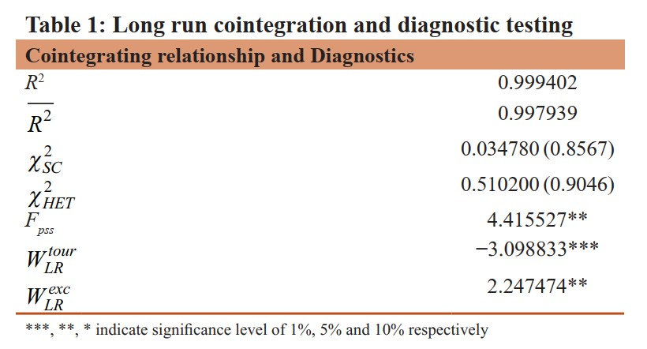

[output not shown]